# bastln mitochondrial genes against their contigs

I have two main questions I am working through right now:

1. How do I select which genes to annotate
2. Why are there so many ND# mt genes with issues?

## Exploratory analysis of blastn data

Here we have blasted (tblstn) translated AA mtDNA genes identified with mitofinder against the UCE contigs they were found in. About half of the assembled contigs threw a warning from mitofinder, indicating they might be contaminated, fragmented, or NUMTS are present and need to be checked. I’ve already checked for contamination and identified a couple samples to remove. The aim now is to find which contigs we should analyize for NUMTs and fragmentation. I added two additional columns with the sample name_id and gene at the end of the dataframe before importing the dataframe

**dependant packages**

```r
library(readr)
library(dplyr)
library(tidyverse)
library(ggplot2)
```

**Load data**

```r
d <- read.csv("blastn_analysis.csv")
dim(d)
```

```
## [1] 1547   14
```

### Take into account percentage of identity and length

Lets look at the percentage of identity times the length of the match; and then plot that against the bitscore.

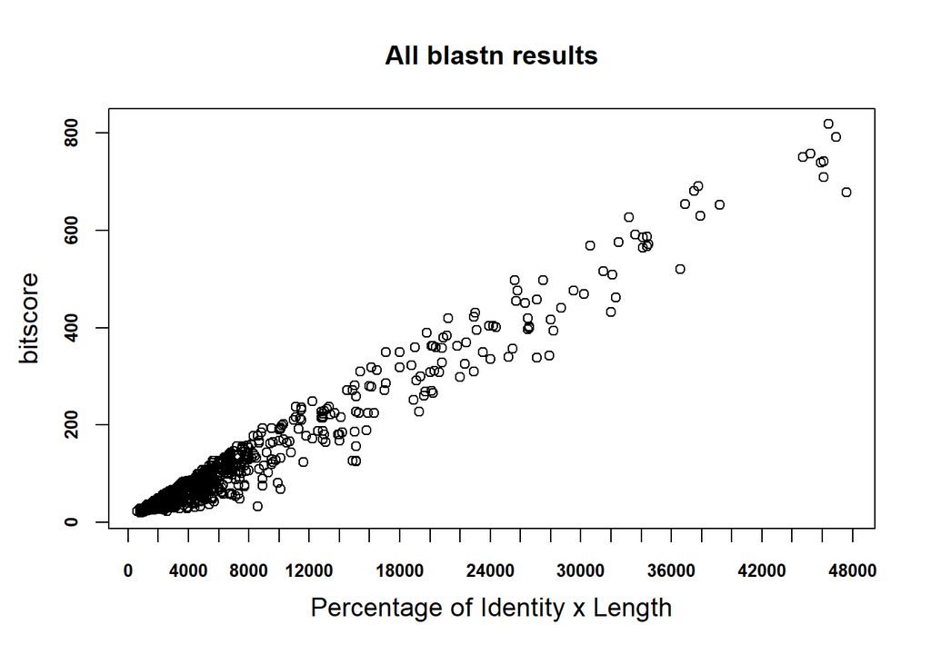

```r
plot(d$pident * d$length, d$bitscore, xaxt = "n", yaxt="n", xlab="",ylab="")
  axis(1, xaxp=c(0,50000, 25), las=1, font=2, cex.axis=0.8)
  axis(2, font=2, cex.axis=0.8)
#mtext(side = 1, line=1, "Percentage of Identity x Length", font=2, cex=1.2)
title(main="All blastn results",cex.lab=1.2)
title(ylab="bitscore",
      xlab="Percentage of Identity x Length",
      cex.lab=1.2, line =2.5)
```

This makes sense, the longer the tblastn match, the more confident we are about the match.

## plot all alle genes this way

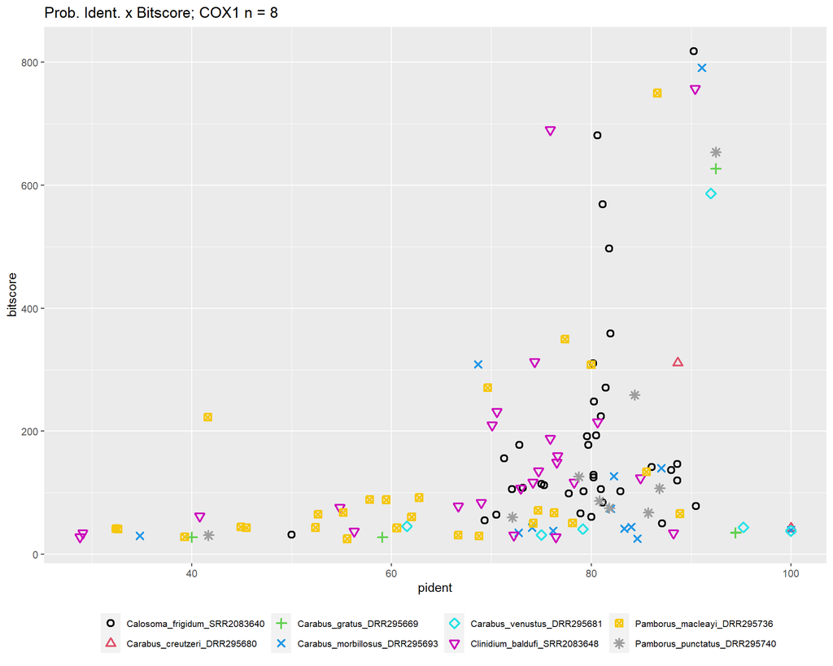

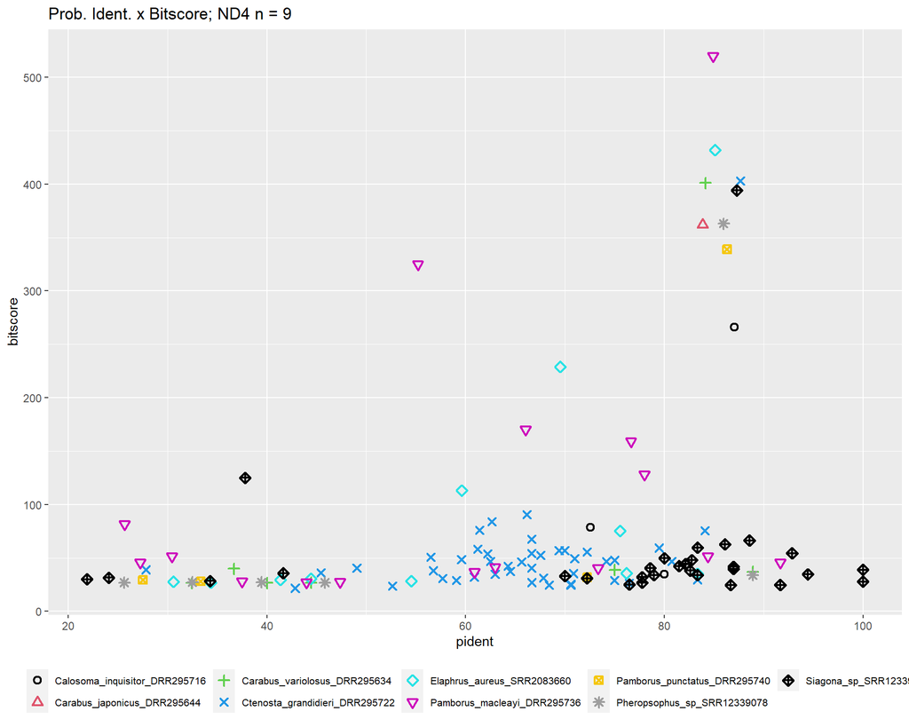

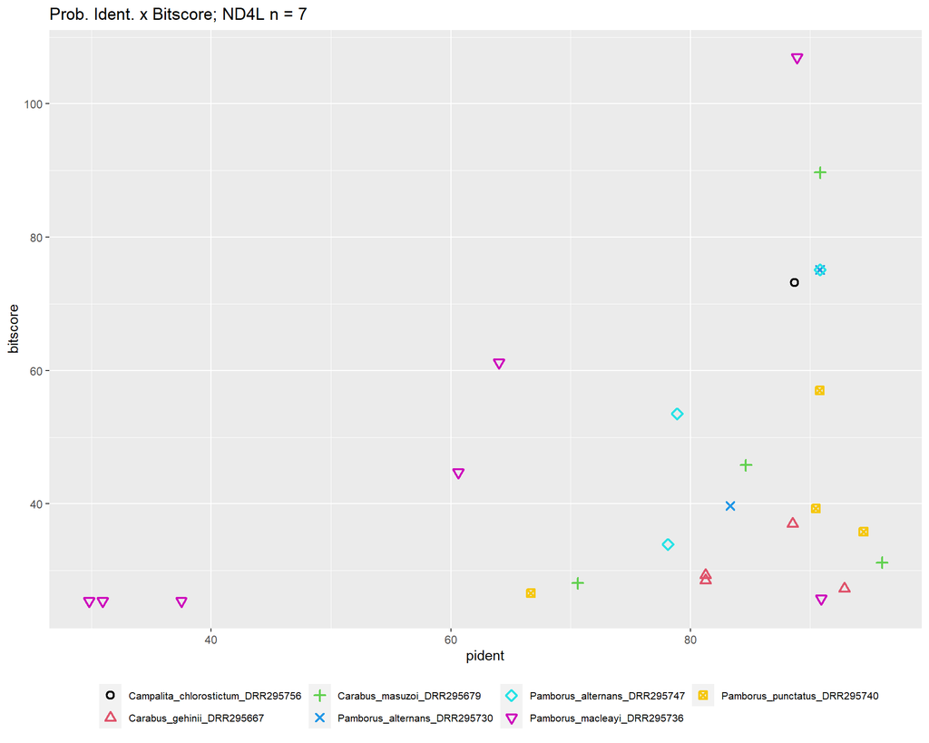

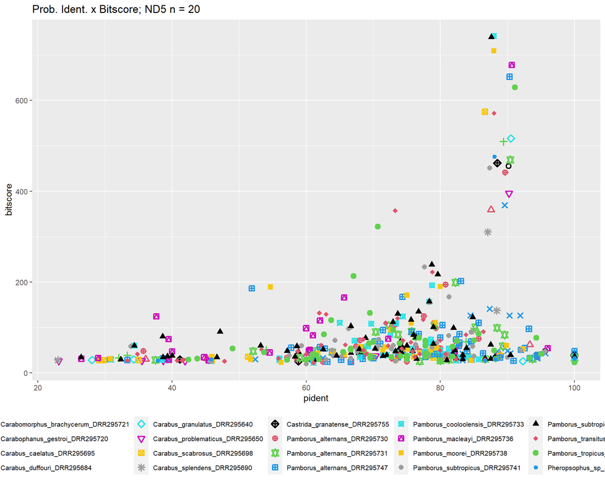

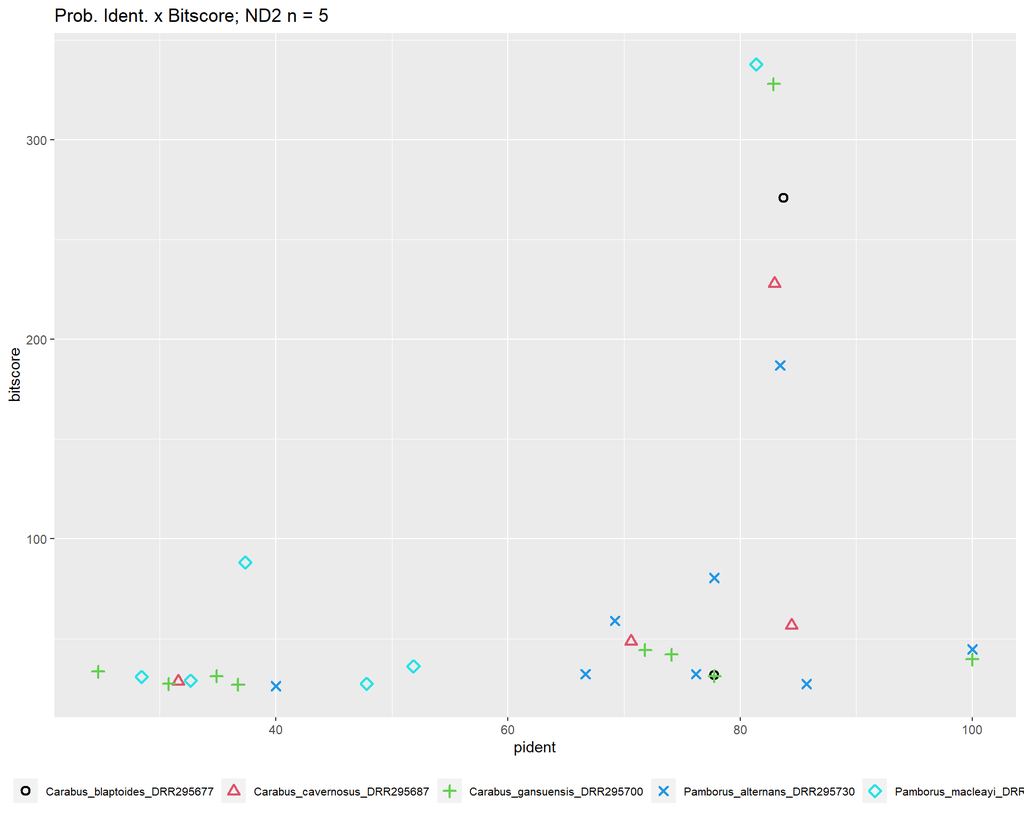

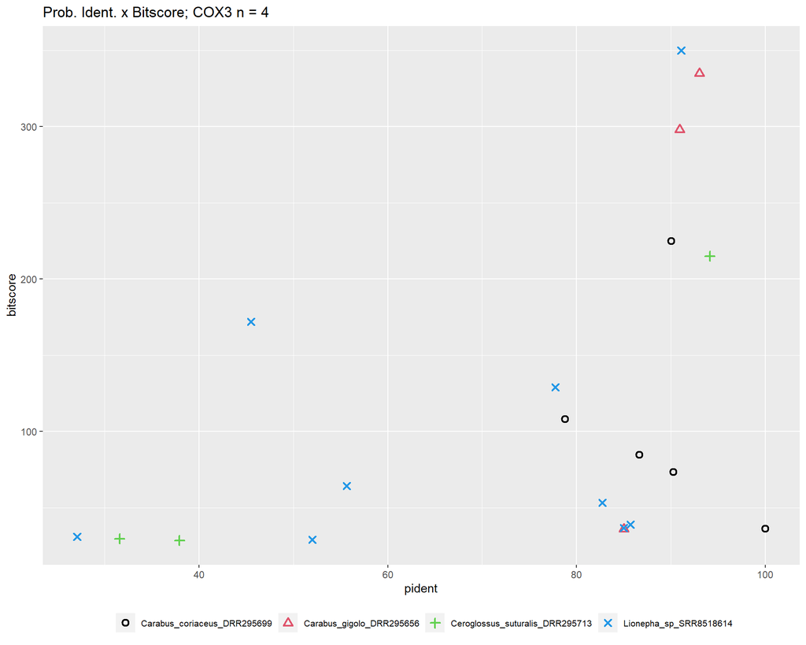

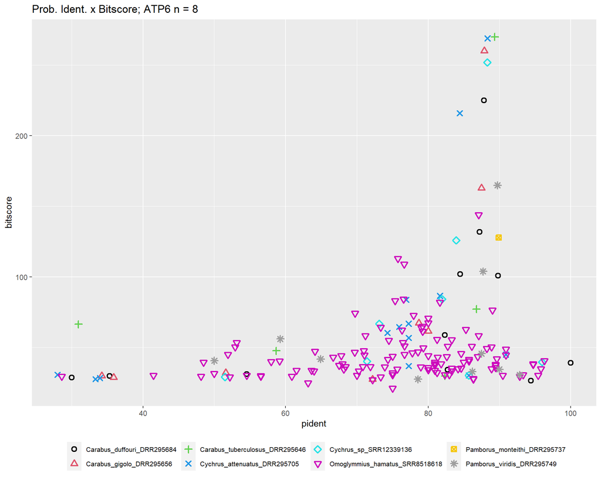

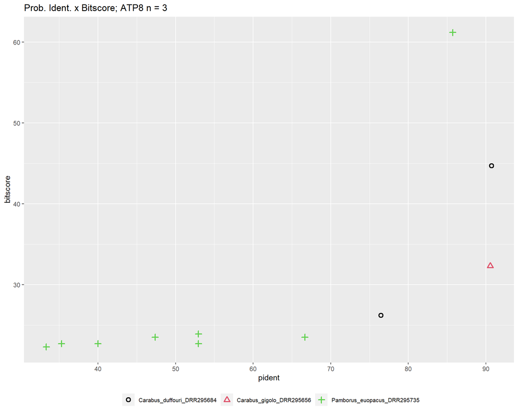

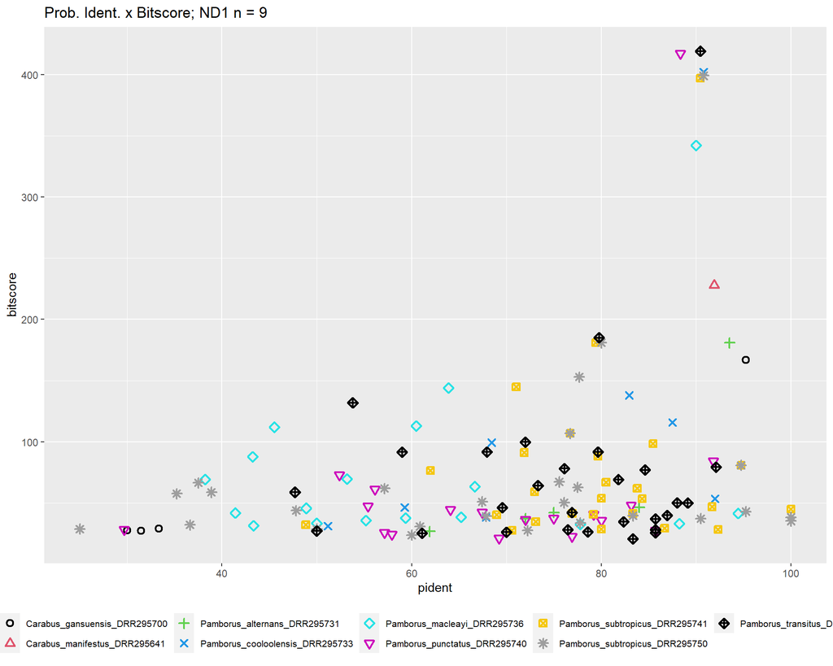

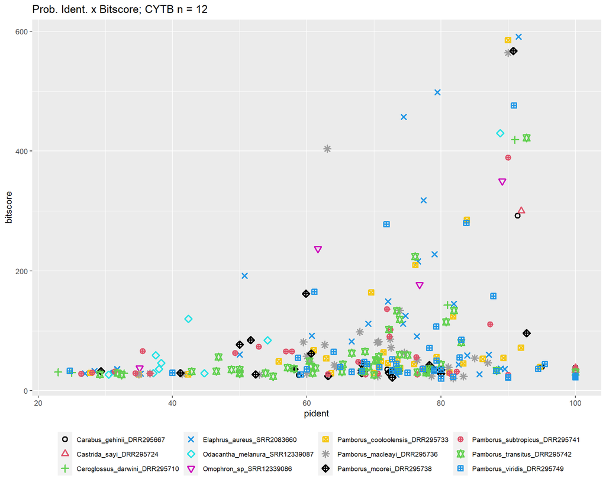

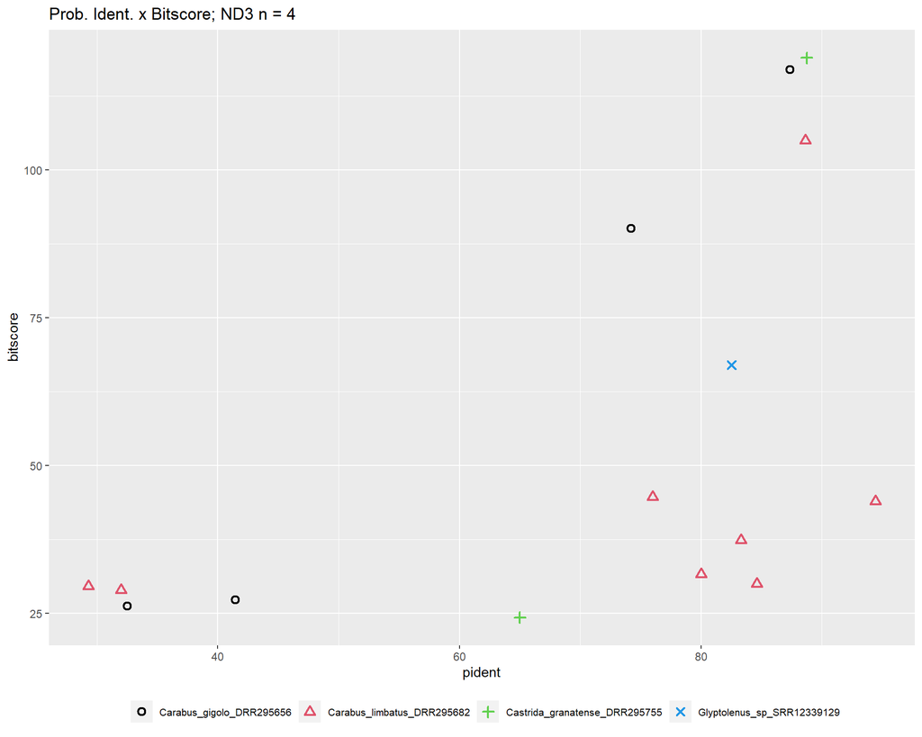

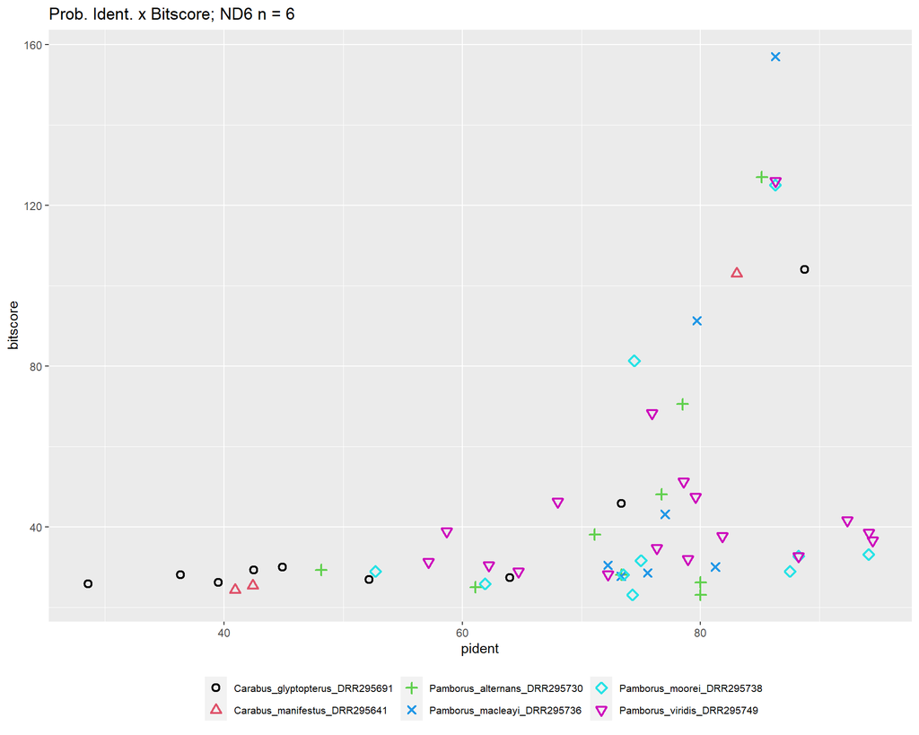

[1 more figures not shown]

```r
genes<-unique(d$gene)

for(i in genes){
  length <- d %>% filter(gene==i) %>% nrow()
  n <- d %>% filter(gene==i) %>% distinct(id) %>% nrow()
  list1 <- d %>% filter(gene==i) %>%
    ggplot(., aes(x= pident, y=bitscore)) +
    geom_point(size=2, stroke=1.3,
               aes(shape=id,color=id)) +
    scale_shape_manual(values=1:n) +
    scale_color_manual(values=1:n) +
    theme(legend.title = element_blank(), legend.text=element_text(size=8),
          legend.position="bottom") +
    ggtitle(paste("Prob. Ident. x Bitscore;",i,"n =",n))
  print(list1)
}
```

Need to think about how to intemperate this, if anything can be interpreted at all.

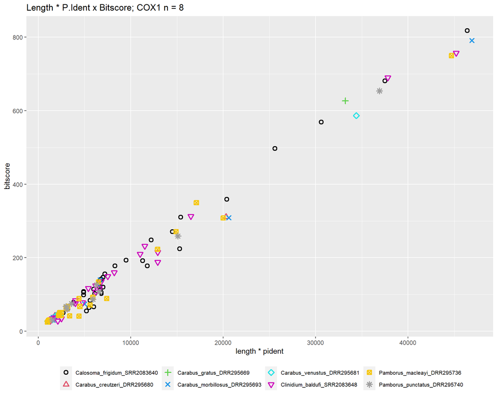

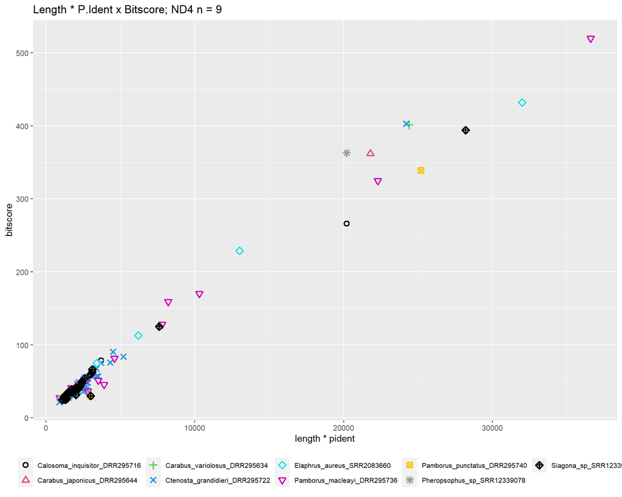

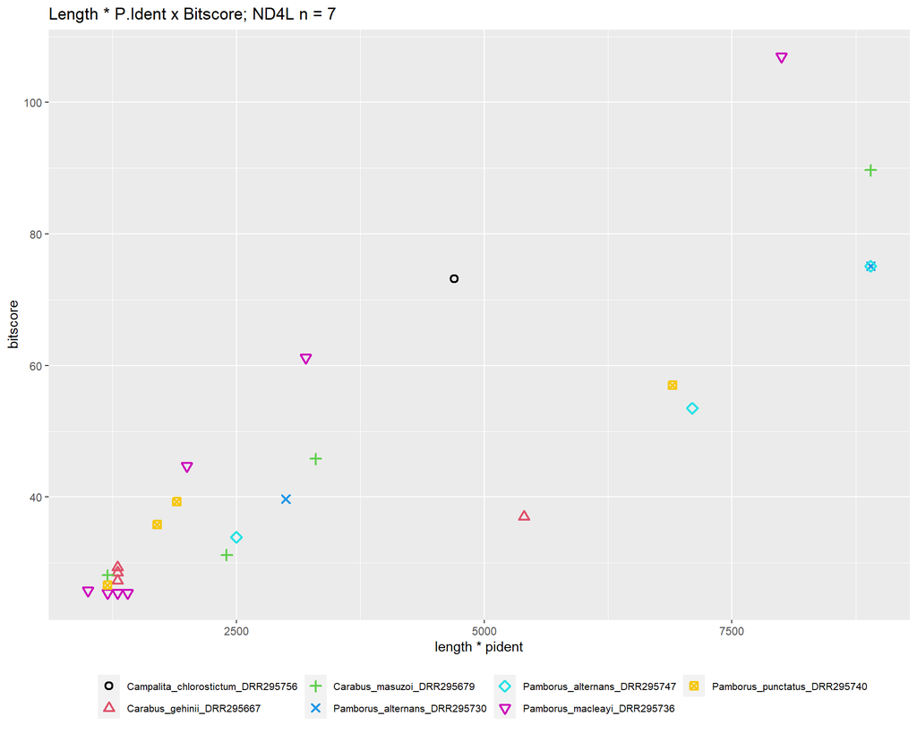

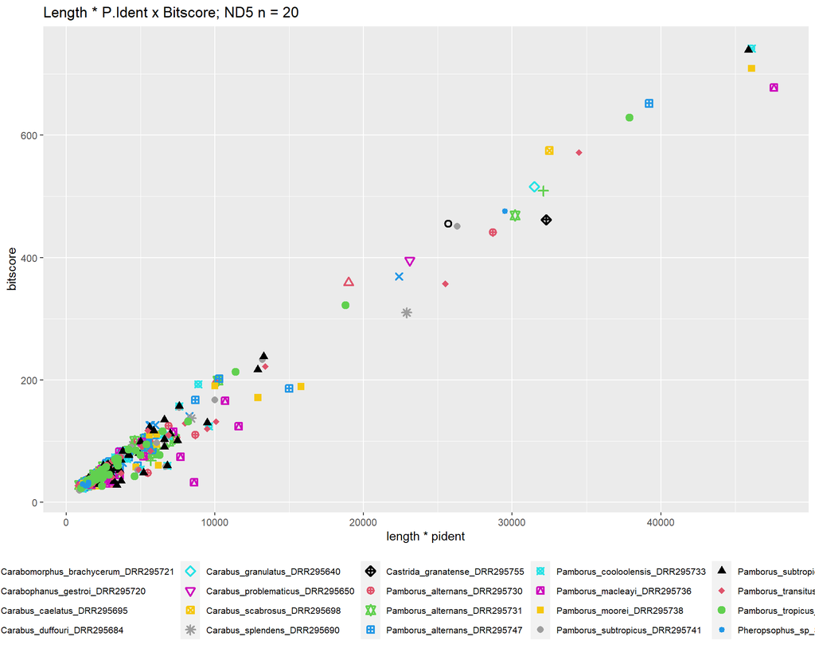

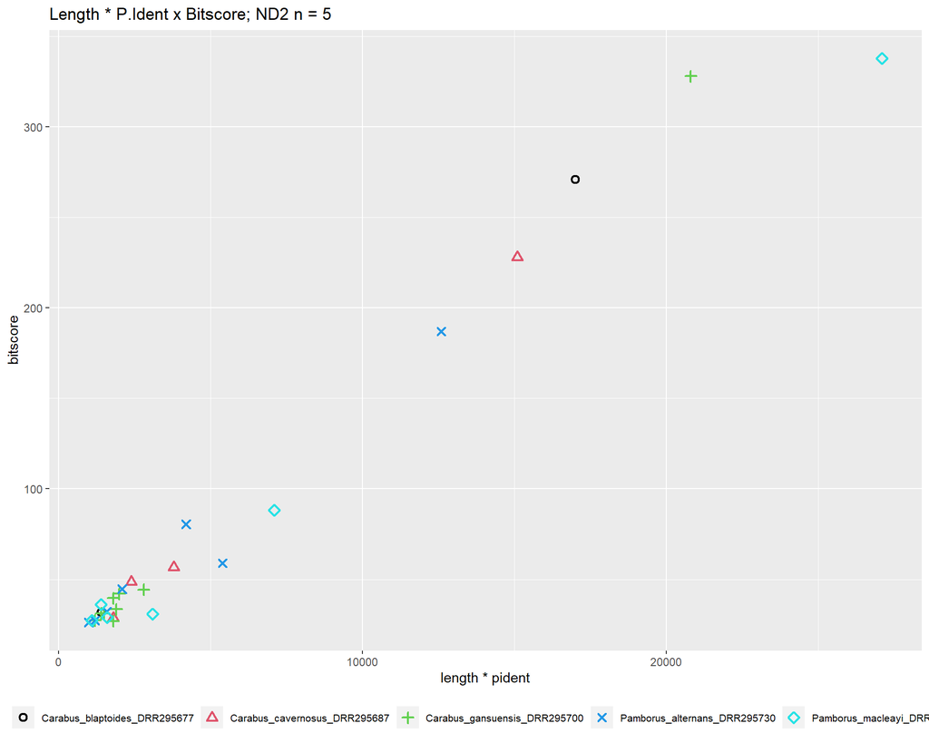

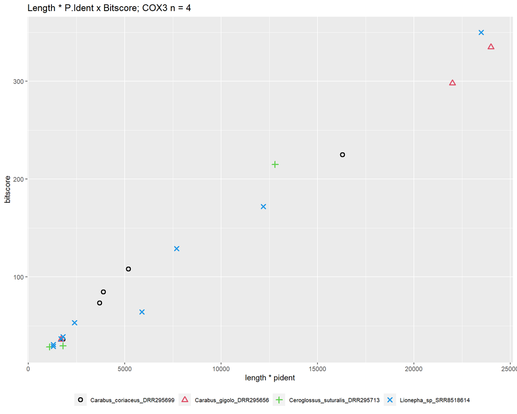

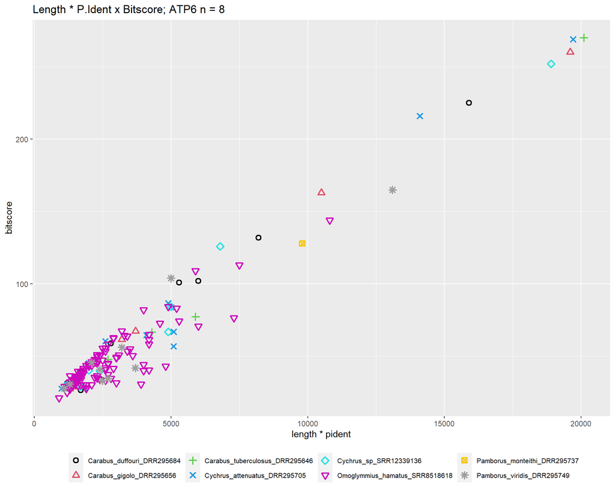

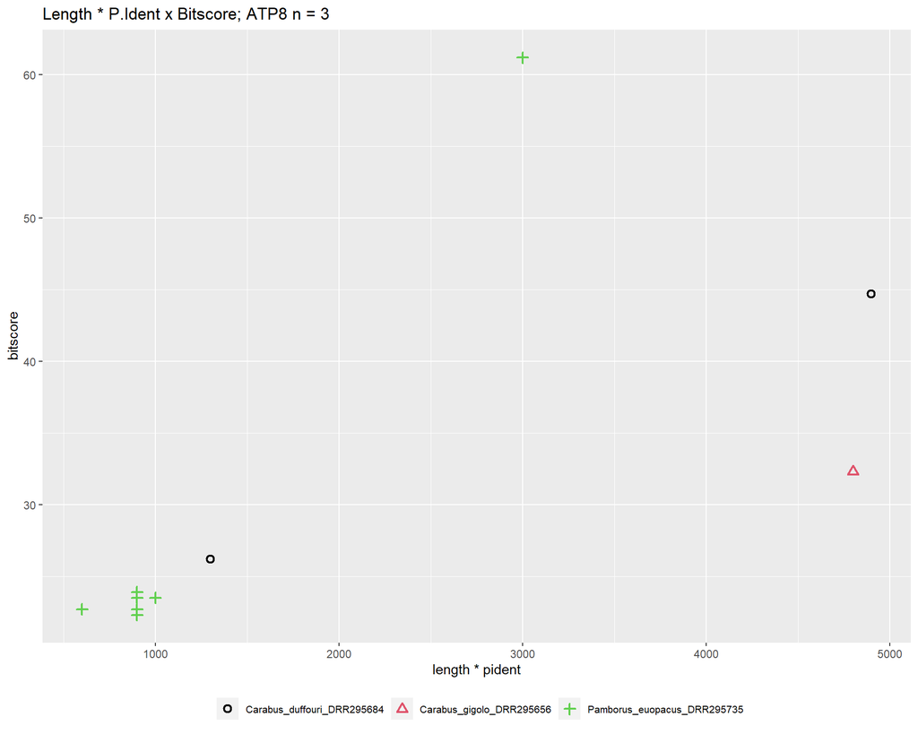

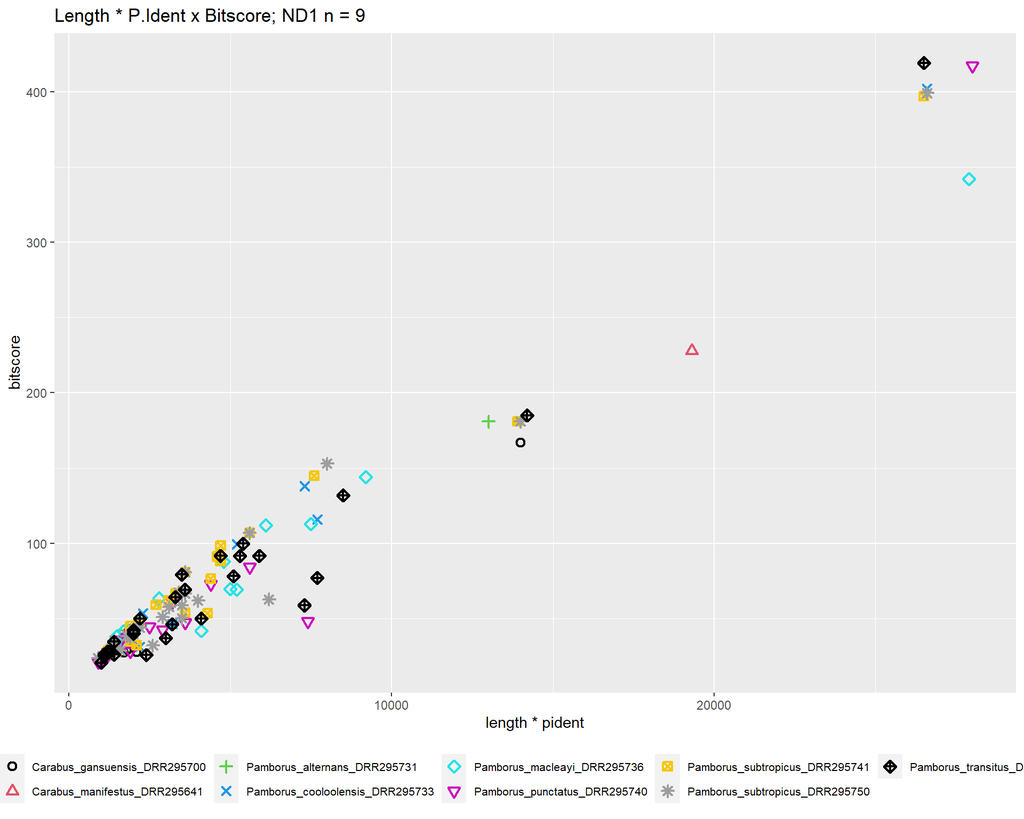

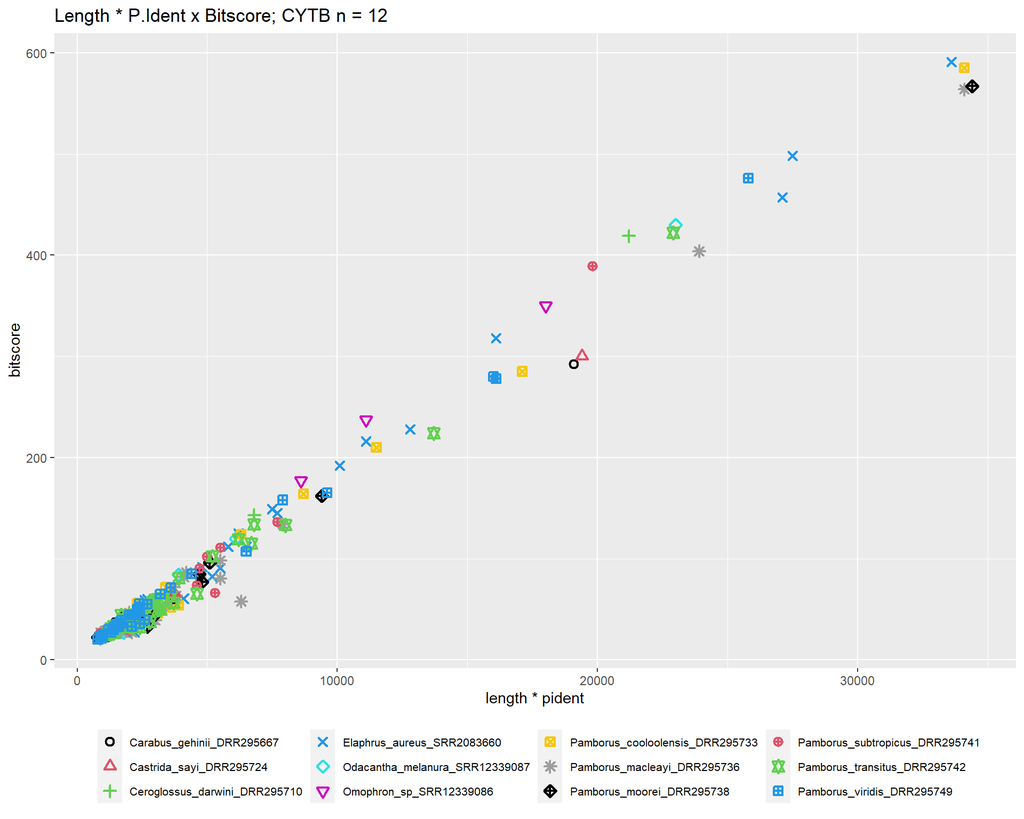

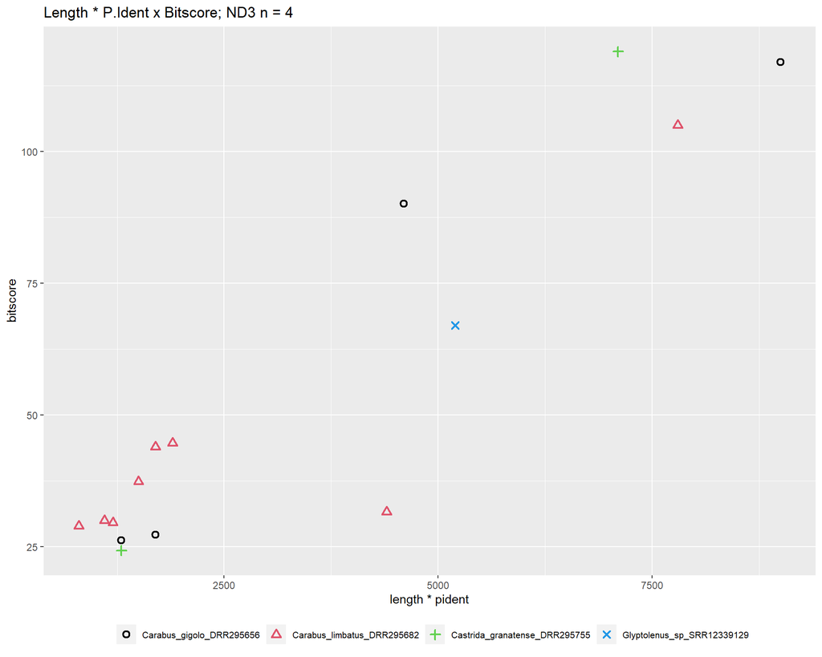

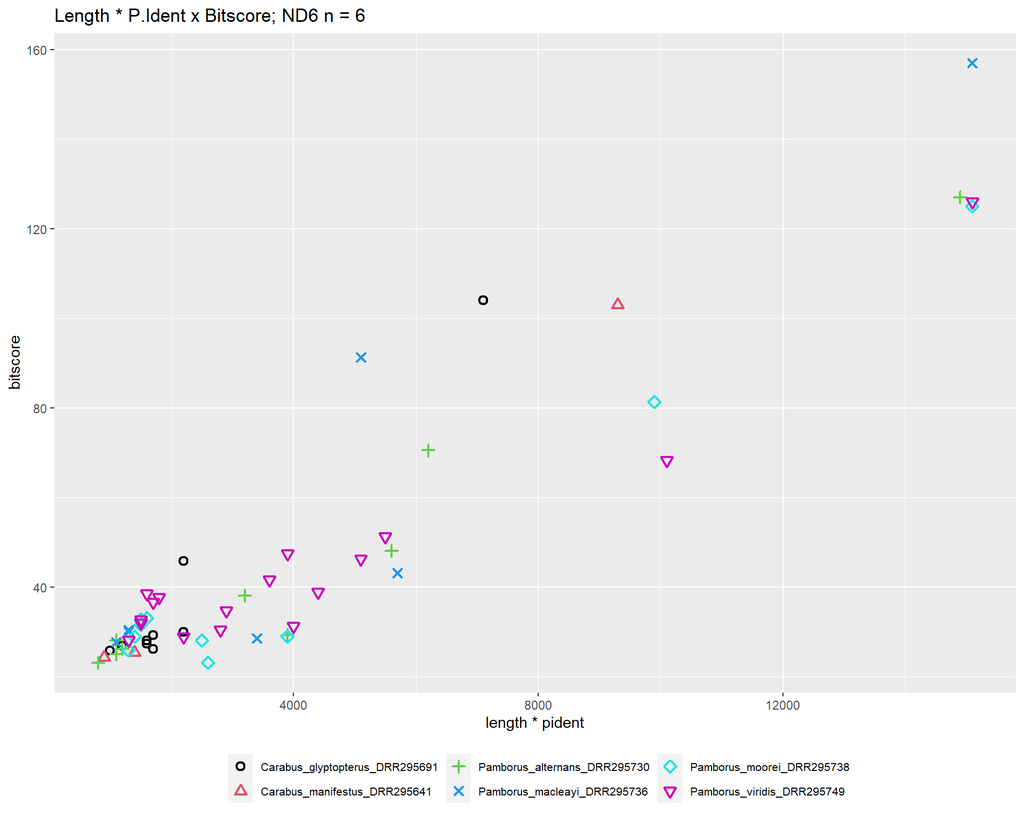

[1 more figures not shown]

```r
genes<-unique(d$gene)

for(i in genes){
  length <- d %>% filter(gene==i) %>% nrow()
  n <- d %>% filter(gene==i) %>% distinct(id) %>% nrow()
  list1 <- d %>% filter(gene==i) %>%
    ggplot(., aes(x=length * pident, y=bitscore)) +
    geom_point(size=2, stroke=1.3,
               aes(shape=id,color=id)) +
    scale_shape_manual(values=1:n) +
    scale_color_manual(values=1:n) +
    theme(legend.title = element_blank(), legend.text=element_text(size=8),
          legend.position="bottom") +
    ggtitle(paste("Length * P.Ident x Bitscore;",i,"n =",n))
  print(list1)
}
```